# Machine Learning Assignment

Dr. Peter Bradley

April 6, 2016

## Loading data

```r
training <- read.csv("pml-training.csv", stringsAsFactors = TRUE, na.strings=c("", "NA", "#DIV/0"))
testing <- read.csv("pml-testing.csv", stringsAsFactors = TRUE, na.strings=c("", "NA", "#DIV/0"))
```

## Getting and cleaning data

First, the data comes to us already separated into ‘training’ and ‘testing’ sets. The training set is loaded, and the testing set aside until the model is complete.

This data is not pristene—some of the columns contain empty strings, which need to be idenfied as ‘NA’. Second, there are some variables named ‘kurtosis’ which are processed as strings, because they contain “#DIV/0”. We’ll fix both of these problems at import using ‘na.strings’. Since we’ve removed all the string variables except the ‘classe’ variable, which is our target, we can make classe a factor at import with ‘stringsAsFactors = TRUE’.

The training table has a large number of rows with NA’s or blank values - 19216 rows to be exact. We do not want to remove these rows, as that would greatly hamper the development of our model.

Instead, we want to ignore the variables for which these 19216 rows are blank.

```r
findNull <- function(y) { sum(length(which(is.na(y) ))) }
na_count <- do.call(rbind, lapply(training, findNull))
na_count <- as.data.frame(na_count)
na_count$name <- rownames(na_count)
#na_count[na_count$V1 > 0,]$name
which(na_count$V1 > 0) -> varsToIgnore
```

Now we remove the record keeping variables ‘X’, ‘username’, *timestamp*, ‘new_window’ and ‘num_window’.

```r
set.seed(424242)
varsToIgnore <- c(1,2,3,4,5,6,7,varsToIgnore)
#summary(training[, -varsToIgnore])
training[, -varsToIgnore] -> newtrainingset
```

## Building the Model

```r
training[, -varsToIgnore] -> newtrainingset
subTrain <- createDataPartition(y=newtrainingset$classe, p=0.7, list=FALSE)
subTrain1 <- newtrainingset[subTrain,]
subTrain2 <- newtrainingset[-subTrain,]
```

Before building the model, we split the training set into two, to allow cross-validation without introducing the testing set to the process of building the model. 13737 with 53 variables were used for training, 5885 with 53 variables were used for cross-validation..

Models initially tested against all variables included Trees, Random Forest, Linear Disciminant Analysis and Naive Bayes.[^1]

```r
#modFitTrees <- train(classe ~  ., data=subTrain1, method="rpart")
#modFitRF1 <- train(classe ~  ., data=subTrain1, method="rf")
#modFitLDA <- train(classe ~  ., data=subTrain1, method="lda")
#modFitNB <- train(classe ~  ., data=subTrain1, method="nb")
```

The accuracy of the resultant models except for Random Forest left something to be desired:

```r
#modFitTrees$results['Accuracy'][1,]
#modFitRF1$results['Accuracy'][1,]
#modFitLDA$results['Accuracy'][1,]
#modFitNB$results['Accuracy'][1,]
```

| Model Type | Accuracy |
| --- | --- |
| Trees | 50.32% |
| RF1 | 98.76% |
| LDA | 70.35% |
| NB | 51.34% |

```r
#modFitGBM1 <- train(classe ~  ., data=subTrain1, method="gbm", verbose=FALSE)
```

To improve the model, we tried Generalized Boosted Models, or ’gbm, which produced an initially exiciting accuracy of 75.00%

### Selection of relevant variables

```r
varsToInclude <- c("roll_belt", "pitch_forearm", "yaw_belt", "magnet_dumbbell_y", "magnet_dumbbell_z", "roll_forearm", "magnet_belt_z", "gyros_belt_z", "pitch_belt", "roll_dumbbell","classe")

varsToExtend <- c("accel_forearm_x", "accel_dumbbell_y", "gyros_dumbbell_y", "magnet_arm_z", "magnet_forearm_z", "accel_dumbbell_x", "yaw_arm", "magnet_dumbbell_x", "accel_forearm_z", "magnet_belt_y")
```

```r
modFitRF2 <- train(classe ~  roll_belt + pitch_forearm + yaw_belt + magnet_dumbbell_y + magnet_dumbbell_z + roll_forearm + magnet_belt_z + gyros_belt_z + pitch_belt + roll_dumbbell  + accel_forearm_x + accel_dumbbell_y + gyros_dumbbell_y + magnet_arm_z + magnet_forearm_z + accel_dumbbell_x + yaw_arm + magnet_dumbbell_x + accel_forearm_z + magnet_belt_y, data=subTrain1, method="rf")
#modFitRF3 <- train(classe ~  roll_belt + pitch_forearm + yaw_belt + magnet_dumbbell_y + magnet_dumbbell_z + roll_forearm + magnet_belt_z + gyros_belt_z + pitch_belt + roll_dumbbell, data=subTrain1, method="rf")
#modFitGBM2 <- train(classe ~  roll_belt + pitch_forearm + yaw_belt + magnet_dumbbell_y + magnet_dumbbell_z + roll_forearm + magnet_belt_z + gyros_belt_z + pitch_belt + roll_dumbbell  + accel_forearm_x + accel_dumbbell_y + gyros_dumbbell_y + magnet_arm_z + magnet_forearm_z + accel_dumbbell_x + yaw_arm + magnet_dumbbell_x + accel_forearm_z + magnet_belt_y, data=subTrain1, method="gbm", verbose=FALSE)
#modFitGBM3 <- train(classe ~  roll_belt + pitch_forearm + yaw_belt + magnet_dumbbell_y + magnet_dumbbell_z + roll_forearm + magnet_belt_z + gyros_belt_z + pitch_belt + roll_dumbbell, data=subTrain1, method="gbm", verbose=FALSE)
```

### Cross validation

We also attempted to tune the models by introducing cross validation into the training routine itself using the ‘trControl’ argument to ‘train’. Leave-one-out and repeated K-fold proved too computational intensive for practical use, so we restricted our experimentation to Bootstrap (method=“boot”) and Cross-Validation (method=“cv”).

```r
#train_control <- trainControl(method="boot", number=100)
train_control <- trainControl(method="cv", number=10)
# train_control <- trainControl(method="repeatedcv", number=10, repeats=3)
# repeatedcv is too intensive.
# train_control <- trainControl(method="LOOCV")
# Leave one out is too intensive.
#modFitRF4 <- train(classe ~  roll_belt + pitch_forearm + yaw_belt + magnet_dumbbell_y + magnet_dumbbell_z + roll_forearm + magnet_belt_z + gyros_belt_z + pitch_belt + roll_dumbbell  + accel_forearm_x + accel_dumbbell_y + gyros_dumbbell_y + magnet_arm_z + magnet_forearm_z + accel_dumbbell_x + yaw_arm + magnet_dumbbell_x + accel_forearm_z + magnet_belt_y, data=subTrain1, trControl=trainControl(method="cv"), method="rf")
#modFitGBM4 <- train(classe ~  roll_belt + pitch_forearm + yaw_belt + magnet_dumbbell_y + magnet_dumbbell_z + roll_forearm + magnet_belt_z + gyros_belt_z + pitch_belt + roll_dumbbell, data=subTrain1, method="gbm", trControl=train_control, verbose=FALSE)
```

To cross-validate this finding, we run each model generated on the reserved set of data, and calculate the accuracy.

```r
#trainControl

#subTrain2$predicttrees <- predict(modFitTrees, newdata=subTrain2)
#subTrain2$predictrf1 <- predict(modFitRF1, newdata=subTrain2)
subTrain2$predictrf2 <- predict(modFitRF2, newdata=subTrain2)
#subTrain2$predictrf3 <- predict(modFitRF3, newdata=subTrain2)
#subTrain2$predictrf4 <- predict(modFitRF4, newdata=subTrain2)
#subTrain2$predictgbm1 <- predict(modFitGBM1, newdata=subTrain2)
#subTrain2$predictgbm2 <- predict(modFitGBM2, newdata=subTrain2)
#subTrain2$predictgbm3 <- predict(modFitGBM3, newdata=subTrain2)
#subTrain2$predictgbm4 <- predict(modFitGBM4, newdata=subTrain2)

#subTrain2$predictlda <- predict(modFitLDA, newdata=subTrain2)
#subTrain2$predictnb <- predict(modFitNB, newdata=subTrain2)
```

## Predictions

To test the accuracy of the model, we find the percentage of accurate predictions against the cross-validation set. These are:

```r
#accuracyTrees <- round(sum(subTrain2$predicttrees == subTrain2$classe)/length(subTrain2$classe) * 100,2)
#accuracyrf1 <- round(sum(subTrain2$predictrf1 == subTrain2$classe)/length(subTrain2$classe) * 100,2)
accuracyrf2 <- round(sum(subTrain2$predictrf2 == subTrain2$classe)/length(subTrain2$classe) * 100,2)
#accuracyrf3 <- round(sum(subTrain2$predictrf3 == subTrain2$classe)/length(subTrain2$classe) * 100,2)
#accuracyrf4 <- round(sum(subTrain2$predictrf4 == subTrain2$classe)/length(subTrain2$classe) * 100,2)
#accuracygbm1 <- round(sum(subTrain2$predictgbm1 == subTrain2$classe)/length(subTrain2$classe) * 100,2)
#accuracygbm2 <- round(sum(subTrain2$predictgbm2 == subTrain2$classe)/length(subTrain2$classe) * 100,2)
#accuracygbm3 <- round(sum(subTrain2$predictgbm3 == subTrain2$classe)/length(subTrain2$classe) * 100,2)
#accuracygbm4 <- round(sum(subTrain2$predictgbm4 == subTrain2$classe)/length(subTrain2$classe) * 100,2)
```

| Model | Accuracy |
| --- | --- |
| RF1: | 98.76% |
| RF2: | 99.42% |
| RF3: | 98.5% |
| RF4: | 99.35% |
| GBM1: | 96.52% |
| GBM2: | 95.8% |
| GBM3: | 93.39% |
| GBM4: | 93.63% |

Confusion matrices for the relevant models show the strengths of each:

```r
confusionMatrix(subTrain2$predictrf2, subTrain2$classe)
```

```
## Confusion Matrix and Statistics
##
##           Reference
## Prediction    A    B    C    D    E
##          A 1671    6    0    0    0
##          B    3 1130    5    1    0
##          C    0    3 1016    9    0
##          D    0    0    5  954    2
##          E    0    0    0    0 1080
##
## Overall Statistics
##
##                Accuracy : 0.9942
##                  95% CI : (0.9919, 0.996)
##     No Information Rate : 0.2845
##     P-Value [Acc > NIR] : < 2.2e-16
##
##                   Kappa : 0.9927
##  Mcnemar's Test P-Value : NA
##
## Statistics by Class:
##
##                      Class: A Class: B Class: C Class: D Class: E
## Sensitivity            0.9982   0.9921   0.9903   0.9896   0.9982
## Specificity            0.9986   0.9981   0.9975   0.9986   1.0000
## Pos Pred Value         0.9964   0.9921   0.9883   0.9927   1.0000
## Neg Pred Value         0.9993   0.9981   0.9979   0.9980   0.9996
## Prevalence             0.2845   0.1935   0.1743   0.1638   0.1839
## Detection Rate         0.2839   0.1920   0.1726   0.1621   0.1835
## Detection Prevalence   0.2850   0.1935   0.1747   0.1633   0.1835
## Balanced Accuracy      0.9984   0.9951   0.9939   0.9941   0.9991
```

```r
#confusionMatrix(subTrain2$predictgbm1, subTrain2$classe)
```

### Combining models

As a final attempt to increase the accuracy of the model, we try combining the predictions from the successful RF2 and GBM1 models and retrain it using ‘gam’ method.

```r
#newmodel <- train(classe ~ predictrf2 + predictgbm1 , method="gam", data=subTrain2)
#subTrain2$predictcombined <- predict(newmodel, newdata=subTrain2)
#accuracycombined <- round(sum(subTrain2$predictcombined == subTrain2$classe)/length(subTrain2$classe) * 100,2)
#confusionMatrix(subTrain2$predictcombined, subTrain2$classe) -> newmodelout
#only produces accuracy of 46.4
```

## Conclusion

Thus, the best model on this initial training set is simple random forest model, with a restricted variables included. The predictions versus actual of the cross-validated set are displayed below:

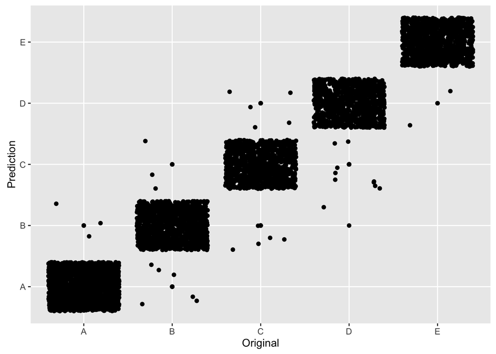

```r
qplot(subTrain2$classe, subTrain2$predictrf2) + geom_jitter() + xlab("Original") + ylab("Prediction")
```

## Final Predictions

```r
testing$predictions <- predict(modFitRF2, testing)
#confusionMatrix(testing$predictions, testing$classe)
testing$predictions
```

```
##  [1] B A B A A E D B A A B C B A E E A B B B
## Levels: A B C D E
```

## Citations

Velloso, E.; Bulling, A.; Gellersen, H.; Ugulino, W.; Fuks, H. Qualitative Activity Recognition of Weight Lifting Exercises. Proceedings of 4th International Conference in Cooperation with SIGCHI (Augmented Human ’13) . Stuttgart, Germany: ACM SIGCHI, 2013.

Read more: http://groupware.les.inf.puc-rio.br/har#ixzz453NWlNvG

[^1]: Due to the constraints of my system, only the final model discussed herein is actually run in the compilation of this document. All values are from previous runs. The R code is left in, but commented out, so the interested reader could, if he or she wanted to verify, run the code on a faster machine.